[figure not shown]

Go back to the main page

# R

## Data Visualization

```r
library("tidyverse")
```

```r
library(kableExtra)
formatted_table <- function(df){
  kbl(df) %>%
  kable_styling(bootstrap_options = c("striped", "hover", "responsive"))
}
```

This file can be found here

> The exercises will be similar to the exercises in Excel in order to compare the results.

### Exercise 1

Load the [Food Emissions](https://www.kaggle.com/datasets/amandaroseknudsen/foodproductemissions?resource=download) data set from Kaggle.

Create a column chart for the `Total Global Average GHG Emissions per kg` per `food product`.

Annotate the axis and add a proper title.

What food product creates the highest Emission value?

```r
file_path_ex1 <- "./files_13_data_visualization_exercises/exercise01/Food_Product_Emissions.csv"
df_ex1 <- read_csv(file_path_ex1)
formatted_table(head(df_ex1))
```

| Food product | Land Use Change | Feed | Farm | Processing | Transport | Packaging | Retail | Total from Land to Retail | Total Global Average GHG Emissions per kg | Unit of GHG Emissions |
| --- | --- | --- | --- | --- | --- | --- | --- | --- | --- | --- |
| Apples | -0.029 | 0.000 | 0.225 | 0.004 | 0.096 | 0.044 | 0.017 | 0.357 | 0.43 | kg CO2e per kg food produced |
| Bananas | -0.025 | 0.000 | 0.266 | 0.059 | 0.292 | 0.065 | 0.021 | 0.678 | 0.86 | kg CO2e per kg food produced |
| Barley | 0.009 | 0.000 | 0.176 | 0.128 | 0.035 | 0.497 | 0.264 | 1.109 | 1.18 | kg CO2e per kg food produced |
| Beef (beef herd) | 16.278 | 1.878 | 39.388 | 1.269 | 0.346 | 0.247 | 0.164 | 59.570 | 99.48 | kg CO2e per kg food produced |
| Beef (dairy herd) | 0.906 | 2.508 | 15.689 | 1.108 | 0.424 | 0.268 | 0.182 | 21.085 | 33.30 | kg CO2e per kg food produced |
| Beet Sugar | 0.000 | 0.000 | 0.536 | 0.242 | 0.629 | 0.090 | 0.039 | 1.536 | 1.81 | kg CO2e per kg food produced |

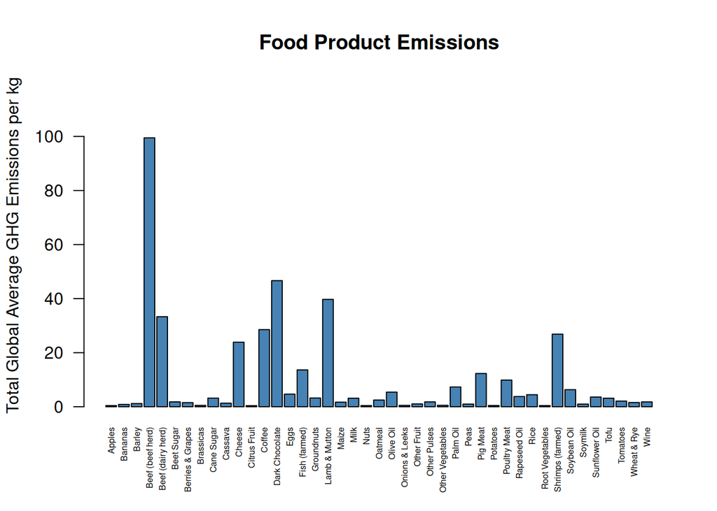

```r
barplot(df_ex1$`Total Global Average GHG Emissions per kg`,
        ylab = "Total Global Average GHG Emissions per kg",
        ylim = c(0, max(df_ex1$`Total Global Average GHG Emissions per kg` + 20)),
        names = df_ex1$`Food product`,
        las = 2,
        cex.names = 0.5,
        col = "steelblue",
        main = "Food Product Emissions")
```

Highest is Beef (Beef Herd)

### Exercise 2

As the differences in the values are rather high, it is wise to use a log scale to display your data. Log scales have their advantages and are often used to display data that cover a wide range of values. Use a 2log scale to display your data.

Example of using log:

```r
log2(8)
```

```
## [1] 3
```

```r
`Log2 Total Global Average GHG Emissions per kg` <- log2(df_ex1$`Total Global Average GHG Emissions per kg`)
df_ex2 <- df_ex1 %>%
  add_column(`Log2 Total Global Average GHG Emissions per kg`)
formatted_table(head(df_ex2))
```

| Food product | Land Use Change | Feed | Farm | Processing | Transport | Packaging | Retail | Total from Land to Retail | Total Global Average GHG Emissions per kg | Unit of GHG Emissions | Log2 Total Global Average GHG Emissions per kg |
| --- | --- | --- | --- | --- | --- | --- | --- | --- | --- | --- | --- |
| Apples | -0.029 | 0.000 | 0.225 | 0.004 | 0.096 | 0.044 | 0.017 | 0.357 | 0.43 | kg CO2e per kg food produced | -1.2175914 |
| Bananas | -0.025 | 0.000 | 0.266 | 0.059 | 0.292 | 0.065 | 0.021 | 0.678 | 0.86 | kg CO2e per kg food produced | -0.2175914 |
| Barley | 0.009 | 0.000 | 0.176 | 0.128 | 0.035 | 0.497 | 0.264 | 1.109 | 1.18 | kg CO2e per kg food produced | 0.2387869 |
| Beef (beef herd) | 16.278 | 1.878 | 39.388 | 1.269 | 0.346 | 0.247 | 0.164 | 59.570 | 99.48 | kg CO2e per kg food produced | 6.6363346 |
| Beef (dairy herd) | 0.906 | 2.508 | 15.689 | 1.108 | 0.424 | 0.268 | 0.182 | 21.085 | 33.30 | kg CO2e per kg food produced | 5.0574503 |
| Beet Sugar | 0.000 | 0.000 | 0.536 | 0.242 | 0.629 | 0.090 | 0.039 | 1.536 | 1.81 | kg CO2e per kg food produced | 0.8559897 |

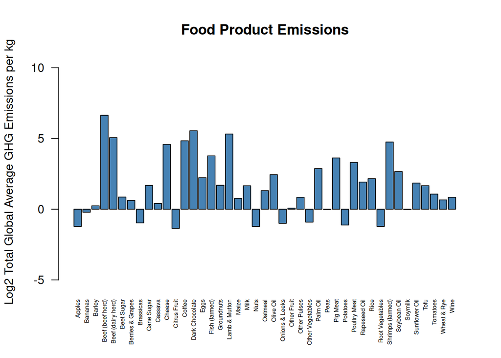

```r
barplot(df_ex2$`Log2 Total Global Average GHG Emissions per kg`,
        ylab = "Log2 Total Global Average GHG Emissions per kg",
        ylim = c(min(df_ex2$`Log2 Total Global Average GHG Emissions per kg` - 4), max(df_ex2$`Log2 Total Global Average GHG Emissions per kg` + 4)),
        names = df_ex2$`Food product`,
        las = 2,
        cex.names = 0.5,
        col = "steelblue",
        main = "Food Product Emissions")
```

Note that this plot differs from the Excel counterpart. Here I calculated the 2log values (for example: the highest value is around 100. log2(100) = 6.6) and plotted the 2log GHG values on a linear y-scale while in the Excel counterpart, I plotted the GHG values on a 2log scaled y-axis. Both are permitted as long as you clearly indicate what is plotted on the y-axis. Note that values below 1 become negative on a log scale (log2(1) = 0 and log2(0.5) = -1).

### Exercise 3

From the previous data set, filter the data that contain oil in the name.  
Create a clustered column chart representing the Emissions per kg from `Farm`, `Processing`, `Transport`, `Packaging` and `Retail`. Make sure to add proper axis titles, a title and a legend.

First we create a df with the rows of Oil products:

```r
df_ex3 <- df_ex1[str_detect(df_ex1$`Food product`, "Oil"), ]
formatted_table(df_ex3)
```

| Food product | Land Use Change | Feed | Farm | Processing | Transport | Packaging | Retail | Total from Land to Retail | Total Global Average GHG Emissions per kg | Unit of GHG Emissions |
| --- | --- | --- | --- | --- | --- | --- | --- | --- | --- | --- |
| Olive Oil | -0.377 | 0 | 4.272 | 0.660 | 0.482 | 0.861 | 0.046 | 5.944 | 5.42 | kg CO2e per kg food produced |
| Palm Oil | 3.096 | 0 | 2.107 | 1.264 | 0.208 | 0.886 | 0.044 | 7.605 | 7.32 | kg CO2e per kg food produced |
| Rapeseed Oil | 0.212 | 0 | 2.343 | 0.193 | 0.190 | 0.844 | 0.046 | 3.828 | 3.77 | kg CO2e per kg food produced |
| Soybean Oil | 3.096 | 0 | 1.519 | 0.311 | 0.299 | 0.849 | 0.043 | 6.117 | 6.32 | kg CO2e per kg food produced |
| Sunflower Oil | 0.133 | 0 | 2.148 | 0.229 | 0.201 | 0.853 | 0.043 | 3.607 | 3.60 | kg CO2e per kg food produced |

Remove the columns that we do not need:

```r
df_ex3 <- df_ex3 %>%
  select(-`Land Use Change`, -`Feed`)
df_ex3 <- df_ex3[, 1:6]
formatted_table(df_ex3)
```

| Food product | Farm | Processing | Transport | Packaging | Retail |
| --- | --- | --- | --- | --- | --- |
| Olive Oil | 4.272 | 0.660 | 0.482 | 0.861 | 0.046 |
| Palm Oil | 2.107 | 1.264 | 0.208 | 0.886 | 0.044 |
| Rapeseed Oil | 2.343 | 0.193 | 0.190 | 0.844 | 0.046 |
| Soybean Oil | 1.519 | 0.311 | 0.299 | 0.849 | 0.043 |
| Sunflower Oil | 2.148 | 0.229 | 0.201 | 0.853 | 0.043 |

Make the df tidy:

```r
tidy_df_ex3 <- df_ex3 %>%
  pivot_longer(cols = c("Farm", "Processing", "Transport", "Packaging", "Retail"), names_to = "Emission origin", values_to = "Emission per kg")
formatted_table(head(tidy_df_ex3))
```

| Food product | Emission origin | Emission per kg |
| --- | --- | --- |
| Olive Oil | Farm | 4.272 |
| Olive Oil | Processing | 0.660 |
| Olive Oil | Transport | 0.482 |
| Olive Oil | Packaging | 0.861 |
| Olive Oil | Retail | 0.046 |
| Palm Oil | Farm | 2.107 |

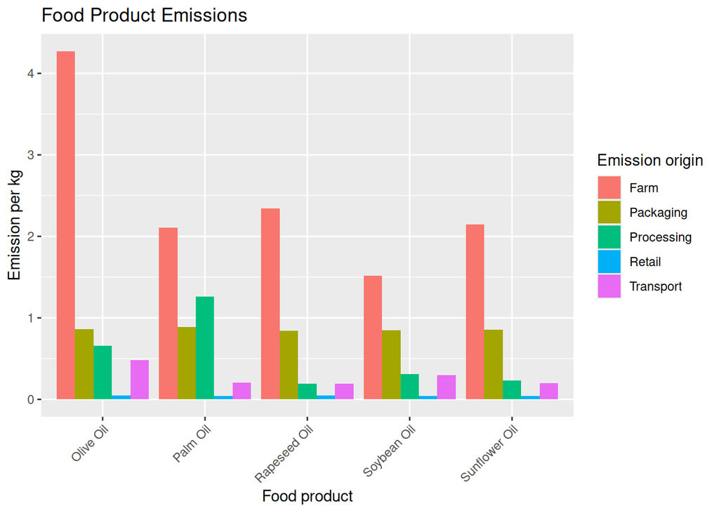

```r
p <- ggplot(data = tidy_df_ex3, aes(x = `Food product`, y = `Emission per kg`, fill = `Emission origin`)) +
  geom_bar(stat = "identity", position="dodge") +
  labs(title="Food Product Emissions") +
  theme(axis.text.x = element_text(angle = 45, hjust=1))
p
```

### Exercise 4

Use the same data as from exercise 3 to create a stacked column chart. Filter the data that contain oil in the name.  
Create a stacked column chart representing the Emissions per kg from `Farm`, `Processing`, `Transport`, `Packaging` and `Retail`. Make sure to add proper axis titles, a title and a legend.

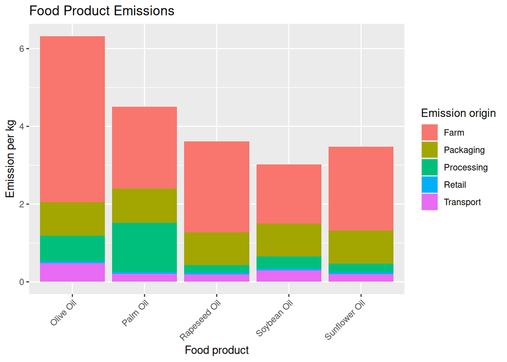

```r
p <- ggplot(data = tidy_df_ex3, aes(x = `Food product`, y = `Emission per kg`, fill = `Emission origin`)) +
  geom_bar(stat = "identity", position="stack") +
  labs(title="Food Product Emissions") +
  theme(axis.text.x = element_text(angle = 45, hjust=1))
p
```

### Exercise 5

Use the same data as from exercise 3 to create a relative stacked column chart. Filter the data that contain oil in the name.  
Create a relative stacked column chart representing the Emissions per kg from `Farm`, `Processing`, `Transport`, `Packaging` and `Retail`. Make sure to add proper axis titles, a title and a legend.

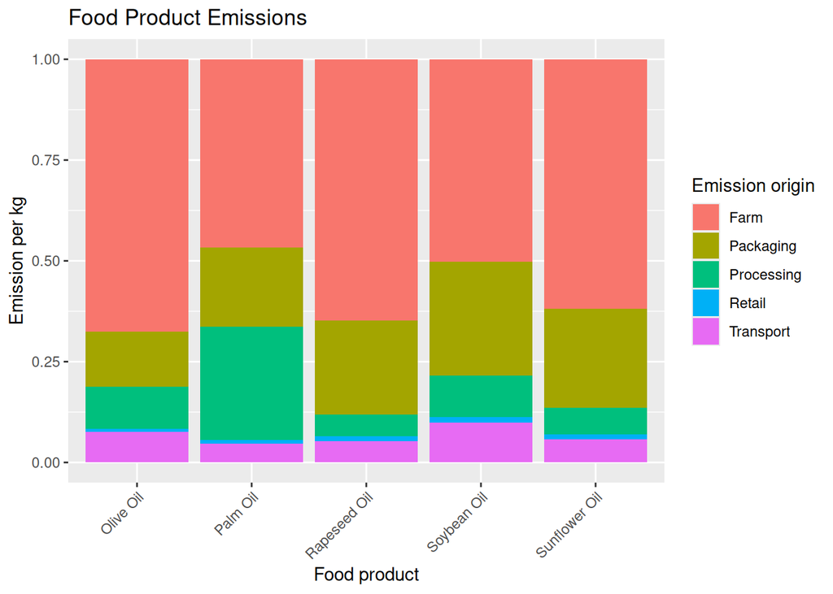

```r
p <- ggplot(data = tidy_df_ex3, aes(x = `Food product`, y = `Emission per kg`, fill = `Emission origin`)) +
  geom_bar(stat = "identity", position="fill") +
  labs(title="Food Product Emissions") +
  theme(axis.text.x = element_text(angle = 45, hjust=1))
p
```

### Exercise 6

Use the same data to create a Pie chart. Filter the data that contain `palmoil` in the name.  
Create a pie chart representing the Emissions per kg from `Farm`, `Processing`, `Transport`, `Packaging` and `Retail`.  
Show the percentages as labels.

Filter for `palmoil` in `Food product`:

```r
tidy_df_ex6 <- tidy_df_ex3 %>%
  filter(str_detect(`Food product`, "Palm Oil"))
formatted_table(head(tidy_df_ex6))
```

| Food product | Emission origin | Emission per kg |
| --- | --- | --- |
| Palm Oil | Farm | 2.107 |
| Palm Oil | Processing | 1.264 |
| Palm Oil | Transport | 0.208 |
| Palm Oil | Packaging | 0.886 |
| Palm Oil | Retail | 0.044 |

Calculate the percentages and add to new column:

```r
tidy_df_ex6$percentage <- tidy_df_ex6$`Emission per kg` / sum(tidy_df_ex6$`Emission per kg`) * 100
formatted_table(head(tidy_df_ex6))
```

| Food product | Emission origin | Emission per kg | percentage |
| --- | --- | --- | --- |
| Palm Oil | Farm | 2.107 | 46.7287647 |
| Palm Oil | Processing | 1.264 | 28.0328232 |
| Palm Oil | Transport | 0.208 | 4.6129962 |
| Palm Oil | Packaging | 0.886 | 19.6495897 |
| Palm Oil | Retail | 0.044 | 0.9758261 |

And create the Pie chart:

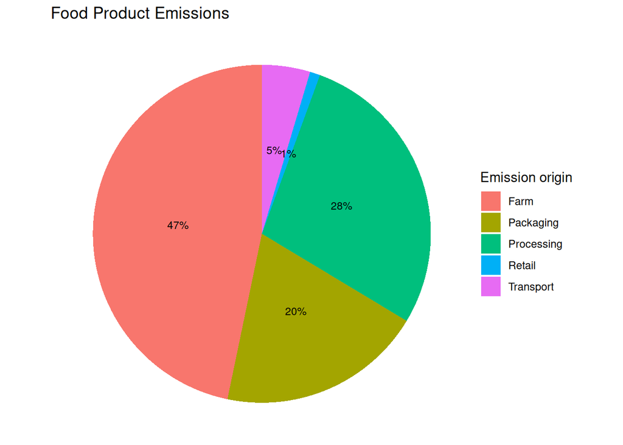

```r
p <- ggplot(tidy_df_ex6, aes(x = "", y = `Emission per kg`, fill = `Emission origin`)) +
  geom_bar(stat = "identity", width = 1) +
  coord_polar("y", start = 0) +
  labs(title = "Food Product Emissions") +
  theme_void() +
  geom_text(aes(label = paste0(round(percentage, 0), "%")), position = position_stack(vjust = 0.5), size = 3)
p
```

Also create a Pie chart for all the oil types showing the Total Global Average GHG Emissions per kg. Show the percentages as labels.

Get the required rows:

```r
df_ex6_2 <- df_ex3 <- df_ex1[str_detect(df_ex1$`Food product`, "Oil"), ]
formatted_table(df_ex6_2)
```

| Food product | Land Use Change | Feed | Farm | Processing | Transport | Packaging | Retail | Total from Land to Retail | Total Global Average GHG Emissions per kg | Unit of GHG Emissions |
| --- | --- | --- | --- | --- | --- | --- | --- | --- | --- | --- |
| Olive Oil | -0.377 | 0 | 4.272 | 0.660 | 0.482 | 0.861 | 0.046 | 5.944 | 5.42 | kg CO2e per kg food produced |
| Palm Oil | 3.096 | 0 | 2.107 | 1.264 | 0.208 | 0.886 | 0.044 | 7.605 | 7.32 | kg CO2e per kg food produced |
| Rapeseed Oil | 0.212 | 0 | 2.343 | 0.193 | 0.190 | 0.844 | 0.046 | 3.828 | 3.77 | kg CO2e per kg food produced |
| Soybean Oil | 3.096 | 0 | 1.519 | 0.311 | 0.299 | 0.849 | 0.043 | 6.117 | 6.32 | kg CO2e per kg food produced |
| Sunflower Oil | 0.133 | 0 | 2.148 | 0.229 | 0.201 | 0.853 | 0.043 | 3.607 | 3.60 | kg CO2e per kg food produced |

And columns:

```r
df_ex6_2 <- df_ex6_2 %>%
  select(`Food product`, `Total Global Average GHG Emissions per kg`)
formatted_table(df_ex6_2)
```

| Food product | Total Global Average GHG Emissions per kg |
| --- | --- |
| Olive Oil | 5.42 |
| Palm Oil | 7.32 |
| Rapeseed Oil | 3.77 |
| Soybean Oil | 6.32 |
| Sunflower Oil | 3.60 |

Calculate the percentages and add to new column:

```r
df_ex6_2$percentage <- df_ex6_2$`Total Global Average GHG Emissions per kg` / sum(df_ex6_2$`Total Global Average GHG Emissions per kg`) * 100
formatted_table(head(df_ex6_2))
```

| Food product | Total Global Average GHG Emissions per kg | percentage |
| --- | --- | --- |
| Olive Oil | 5.42 | 20.50700 |
| Palm Oil | 7.32 | 27.69580 |
| Rapeseed Oil | 3.77 | 14.26409 |
| Soybean Oil | 6.32 | 23.91222 |
| Sunflower Oil | 3.60 | 13.62089 |

And create the Pie chart:

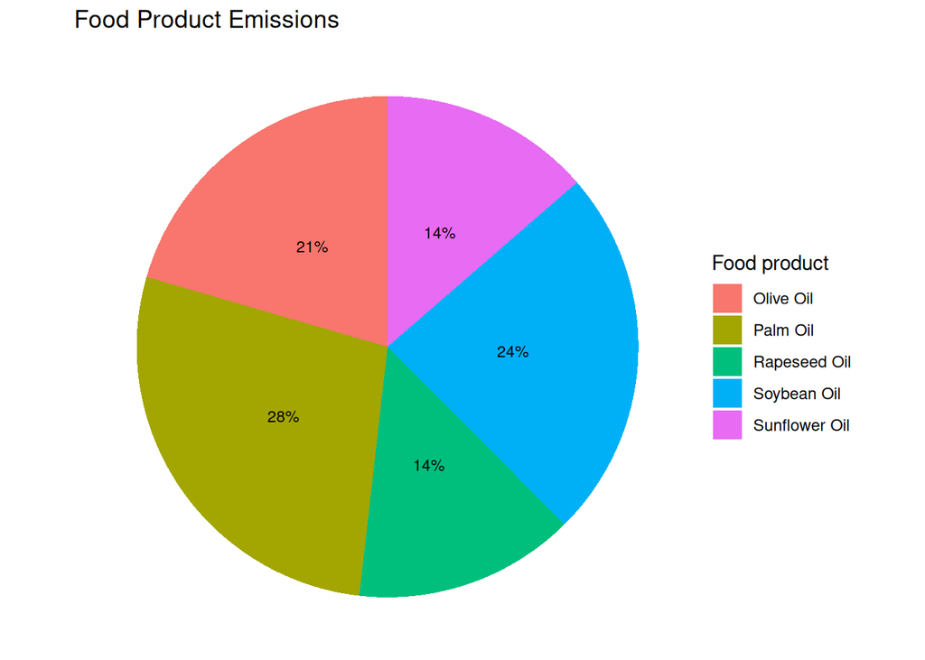

```r
p <- ggplot(df_ex6_2, aes(x = "", y = `Total Global Average GHG Emissions per kg`, fill = `Food product`)) +
  geom_bar(stat = "identity", width = 1) +
  coord_polar("y", start = 0) +
  labs(title = "Food Product Emissions") +
  theme_void() +
  geom_text(aes(label = paste0(round(percentage, 0), "%")), position = position_stack(vjust = 0.5), size = 3)
p
```

### Exercise 7

Download the [data set about](https://www.kaggle.com/datasets/kkhandekar/calories-in-food-items-per-100-grams) food calories per 100 g.

The data set contains units in the cells.  
First clean the data set.  
Create a box plot for `Energy per 100 g in KJ` plotted against the `Food Categories`.

Which two Food Categories show the highest energy per weight?

```r
file_path <- "./files_13_data_visualization_exercises/exercise07/calories.csv"
df_ex7 <- read_csv(file_path)
formatted_table(head(df_ex7))
```

| FoodCategory | FoodItem | per100grams | Cals_per100grams | KJ_per100grams |
| --- | --- | --- | --- | --- |
| CannedFruit | Applesauce | 100g | 62 cal | 260 kJ |
| CannedFruit | Canned Apricots | 100g | 48 cal | 202 kJ |
| CannedFruit | Canned Blackberries | 100g | 92 cal | 386 kJ |
| CannedFruit | Canned Blueberries | 100g | 88 cal | 370 kJ |
| CannedFruit | Canned Cherries | 100g | 54 cal | 227 kJ |
| CannedFruit | Canned Cranberries | 100g | 178 cal | 748 kJ |

Now we need to clean it:

```r
df_ex7 <- df_ex7 %>%
  separate_wider_delim(Cals_per100grams, delim = " ", names = c("Cals_per100grams", "waste")) %>%
  separate_wider_delim(KJ_per100grams, delim = " ", names = c("KJ_per100grams", "waste2")) %>%
  select (-c(waste, waste2)) %>% #Note that this is a negative selection. Selects all but the listed columns.
  mutate_at(c('Cals_per100grams', 'KJ_per100grams'), as.numeric) #Creates numbers from strings
formatted_table(head(df_ex7))
```

| FoodCategory | FoodItem | per100grams | Cals_per100grams | KJ_per100grams |
| --- | --- | --- | --- | --- |
| CannedFruit | Applesauce | 100g | 62 | 260 |
| CannedFruit | Canned Apricots | 100g | 48 | 202 |
| CannedFruit | Canned Blackberries | 100g | 92 | 386 |
| CannedFruit | Canned Blueberries | 100g | 88 | 370 |
| CannedFruit | Canned Cherries | 100g | 54 | 227 |
| CannedFruit | Canned Cranberries | 100g | 178 | 748 |

Create Box plot:

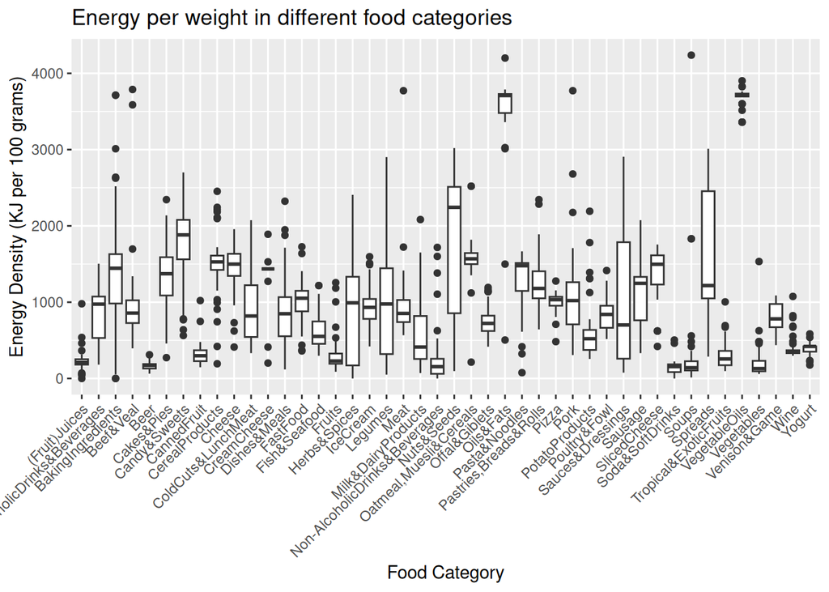

```r
p <- ggplot(df_ex7, aes(x = `FoodCategory`, y = `KJ_per100grams`)) +
  geom_boxplot() +
  labs(title="Energy per weight in different food categories") +
  theme(axis.text.x = element_text(angle = 45, hjust=1)) +
  ylab("Energy Density (KJ per 100 grams)") +
  xlab("Food Category")
p
```

Highest: Oils and Fats and Vegetable Oils

### Exercise 8

In this dataset you can find Chick Weight data. It shows the weight (in grams) on day 42 for various chickens that were fed with various diets during 42 days.

Create a radar chart for the various diets on day 42.  
Calculate the average weight per diet.

Two Chickens on a certain diet clearly gained the most weight.  
Which two chickens on which diet generated the highest weight gains?

```r
file_path <- "./files_13_data_visualization_exercises/exercise08/ChickWeight.csv"
df_ex8 <- read_tsv(file_path)
formatted_table(df_ex8)
```

| …1 | Chick 1 | Chick 2 | Chick 3 | Chick 4 | Chick 5 | Chick 6 | Chick 7 | Chick 8 | Chick 9 |
| --- | --- | --- | --- | --- | --- | --- | --- | --- | --- |
| Diet 1 | 205 | 215 | 202 | 157 | 223 | 157 | 305 | 98 | 124 |
| Diet 2 | 331 | 167 | 175 | 74 | 265 | 251 | 192 | 233 | 309 |
| Diet 3 | 256 | 305 | 147 | 341 | 373 | 220 | 178 | 290 | 272 |
| Diet 4 | 204 | 281 | 200 | 196 | 238 | 205 | 322 | 237 | 264 |

```r
library(ggradar)
```

For a radar chart we need to scale the data from 0-1

```r
df_ex8_scaled <- df_ex8[, -1]/400
formatted_table(df_ex8_scaled)
```

| Chick 1 | Chick 2 | Chick 3 | Chick 4 | Chick 5 | Chick 6 | Chick 7 | Chick 8 | Chick 9 |
| --- | --- | --- | --- | --- | --- | --- | --- | --- |
| 0.5125 | 0.5375 | 0.5050 | 0.3925 | 0.5575 | 0.3925 | 0.7625 | 0.2450 | 0.3100 |
| 0.8275 | 0.4175 | 0.4375 | 0.1850 | 0.6625 | 0.6275 | 0.4800 | 0.5825 | 0.7725 |
| 0.6400 | 0.7625 | 0.3675 | 0.8525 | 0.9325 | 0.5500 | 0.4450 | 0.7250 | 0.6800 |
| 0.5100 | 0.7025 | 0.5000 | 0.4900 | 0.5950 | 0.5125 | 0.8050 | 0.5925 | 0.6600 |

Grab the first column:

```r
first_col <- df_ex8[, 1]
formatted_table(first_col)
```

| …1 |
| --- |
| Diet 1 |
| Diet 2 |
| Diet 3 |
| Diet 4 |

And add together:

```r
df_ex8_mod <- cbind(first_col, df_ex8_scaled)
df_ex8_mod <- df_ex8_mod %>% rename("Diet" = "...1")
formatted_table(df_ex8_mod)
```

| Diet | Chick 1 | Chick 2 | Chick 3 | Chick 4 | Chick 5 | Chick 6 | Chick 7 | Chick 8 | Chick 9 |
| --- | --- | --- | --- | --- | --- | --- | --- | --- | --- |
| Diet 1 | 0.5125 | 0.5375 | 0.5050 | 0.3925 | 0.5575 | 0.3925 | 0.7625 | 0.2450 | 0.3100 |
| Diet 2 | 0.8275 | 0.4175 | 0.4375 | 0.1850 | 0.6625 | 0.6275 | 0.4800 | 0.5825 | 0.7725 |
| Diet 3 | 0.6400 | 0.7625 | 0.3675 | 0.8525 | 0.9325 | 0.5500 | 0.4450 | 0.7250 | 0.6800 |
| Diet 4 | 0.5100 | 0.7025 | 0.5000 | 0.4900 | 0.5950 | 0.5125 | 0.8050 | 0.5925 | 0.6600 |

And now we can create the plot:

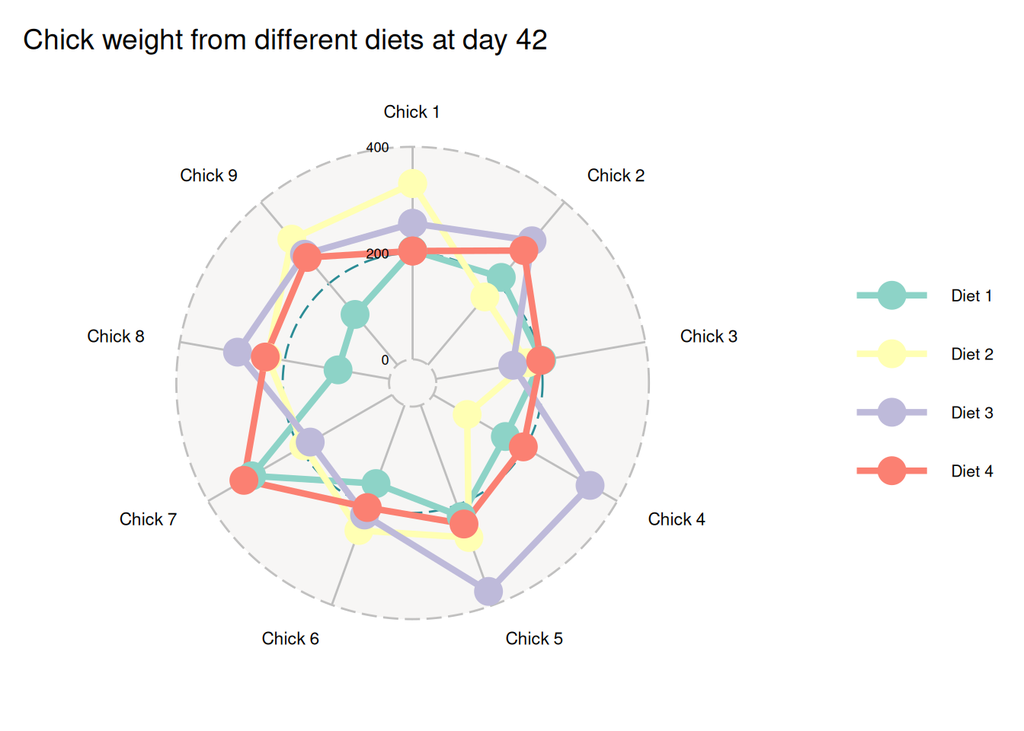

```r
p <- ggradar(df_ex8_mod,  legend.text.size = 8, values.radar = c("0", "200", "400"), axis.label.size = 3, grid.label.size = 3, legend.position = "right") +
  labs(title = "Chick weight from different diets at day 42") +
  theme(plot.title = element_text(size = 14, ))
p
```

Chick 4 and 5 gained the highest weight (on Diet 3).

### Exercise 9

Have look at the data here It contains data about Potassium and Sodium content (in mg/100 g) as well as calories (in kcal/100 g).

The World Health Organization (WHO) recommends ingestion of less than 2000 mg of sodium per day and more than 3510 mg of potassium per day, resulting in a Na-to-K ratio of ≤1.0, which is believed to be optimal for preserving cardiovascular health.

In addition, high caloric food is often bad for cardiovascular health.

As you can see, only the K-to-Na ratio is calculated.  
Create a bubble chart with the Na concentration as a function of the K concentration.  
The bubble size should be based on the calorie values.

Which two food items would be considered most healthy food items based on the information above?

```r
file_path <- "./files_13_data_visualization_exercises/exercise09/data.csv"
df_ex9 <- read_delim(file_path, delim=" ")
df_ex9$...6 <- NULL
formatted_table(head(df_ex9))
```

| Item | Potassium_conc | Sodium_conc | K:Na | Calories |
| --- | --- | --- | --- | --- |
| Almonds | 705 | 1 | 705.0 | 575 |
| Spinach | 558 | 79 | 7.1 | 23 |
| Parsley | 554 | 56 | 9.9 | 36 |
| Cilantro | 521 | 46 | 11.3 | 23 |
| Avocado | 485 | 7 | 69.3 | 160 |
| Crimini | 448 | 6 | 74.7 | 27 |

And now create the plot:

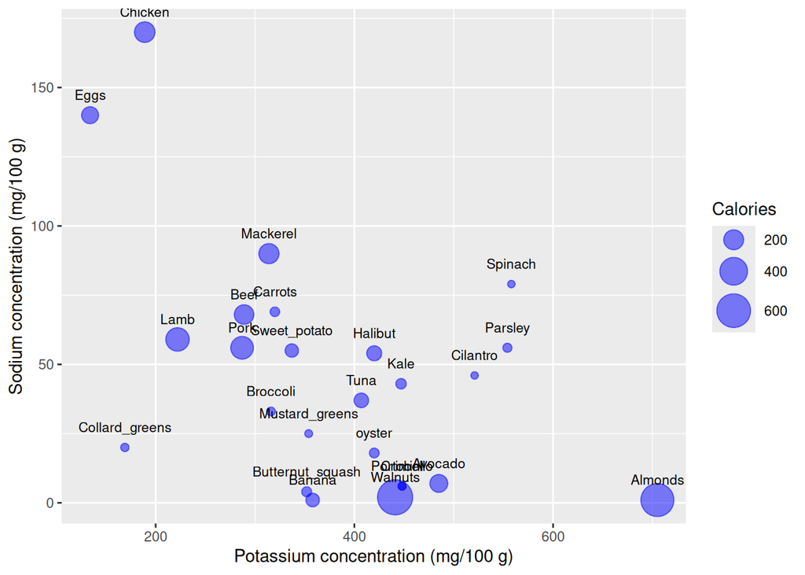

```r
p <- ggplot(df_ex9, aes(x = `Potassium_conc`, y = `Sodium_conc`)) +
  geom_point(aes(size = `Calories`), alpha = 0.5, color = "blue") +
  scale_size_area(max_size = 10) +
  geom_text(aes(label=Item), size = 3, vjust = -1.5) +
  xlab("Potassium concentration (mg/100 g)") +
  ylab("Sodium concentration (mg/100 g)")
p
```

### Exercise 10

In this dataset you can find World wide meat production from 1961 to 2021 expressed in tonnes. It includes cattle, poultry, sheep/mutton, goat, pig meat, and wild game (source: https://ourworldindata.org/meat-production).

Create a XY-scatter plot with the total production of meat (in tonnes) plotted against time for the Asian continent.

Use Scientific notation for the mass meat production.

```r
file_path <- "./files_13_data_visualization_exercises/exercise10/meat-production-tonnes.csv"
df_ex10 <- read_csv(file_path)
df_ex10 <- rename(df_ex10, `Total mass (tonnes)`= `Meat, total | 00001765 || Production | 005510 || tonnes`)
formatted_table(head(df_ex10))
```

| Entity | Code | Year | Total mass (tonnes) |
| --- | --- | --- | --- |
| Afghanistan | AFG | 1961 | 129420 |
| Afghanistan | AFG | 1962 | 132206 |
| Afghanistan | AFG | 1963 | 138971 |
| Afghanistan | AFG | 1964 | 143830 |
| Afghanistan | AFG | 1965 | 150195 |
| Afghanistan | AFG | 1966 | 175210 |

Filter the data to be used:

```r
df_ex10_asia <- df_ex10 %>%
  filter(Entity == "Asia")
formatted_table(head(df_ex10_asia))
```

| Entity | Code | Year | Total mass (tonnes) |
| --- | --- | --- | --- |
| Asia | NA | 1961 | 9034637 |
| Asia | NA | 1962 | 9903225 |
| Asia | NA | 1963 | 11675245 |
| Asia | NA | 1964 | 13275713 |
| Asia | NA | 1965 | 14414256 |
| Asia | NA | 1966 | 15318537 |

Create the plot:

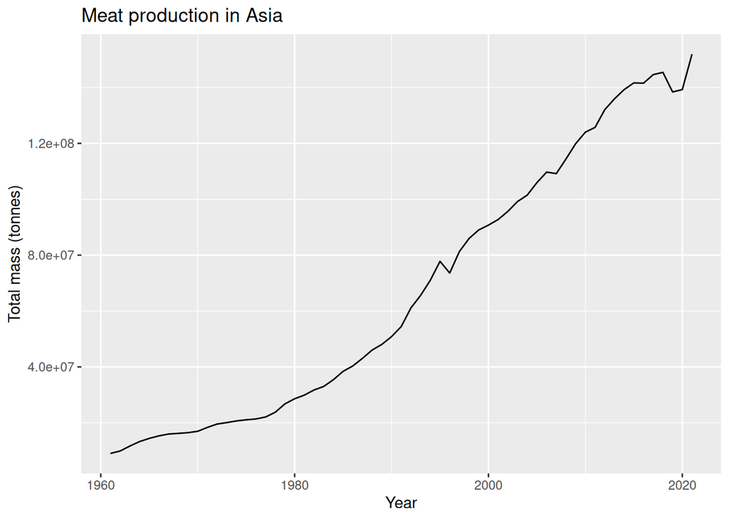

```r
p <- ggplot(data= df_ex10_asia, aes(x = Year, y = `Total mass (tonnes)`)) +
  geom_line() +
  labs(title="Meat production in Asia")
p
```

Or without line (just the data points):

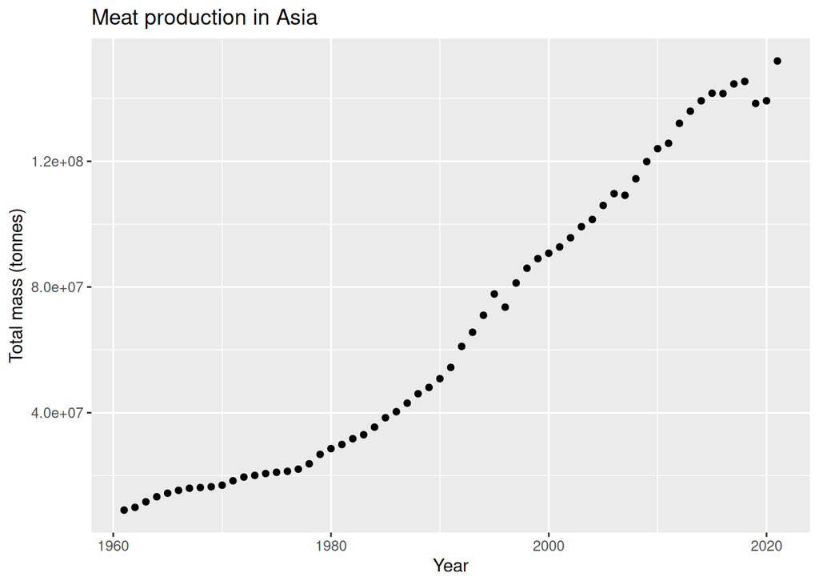

```r
p <- ggplot(data= df_ex10_asia, aes(x = Year, y = `Total mass (tonnes)`)) +
  geom_point() +
  labs(title="Meat production in Asia")
p
```

### Exercise 11

For this exercise, we will use the data set from exercise 7 again. This time, to create a `pivot table and plot` (note that there are no real pivot tables and plots in R).

Download the [data set about](https://www.kaggle.com/datasets/kkhandekar/calories-in-food-items-per-100-grams) food calories per 100 g.

The data set contains units in the cells.  
First clean the data set.  
Create a pivot plot for the **mean** `Energy per 100 g in KJ` plotted against the `Food Categories`.

Which two Food Categories show the highest mean energy per weight?

```r
file_path <- "./files_13_data_visualization_exercises/exercise11/calories.csv"
df_ex11 <- read_csv(file_path)
formatted_table(head(df_ex11))
```

| FoodCategory | FoodItem | per100grams | Cals_per100grams | KJ_per100grams |
| --- | --- | --- | --- | --- |
| CannedFruit | Applesauce | 100g | 62 cal | 260 kJ |
| CannedFruit | Canned Apricots | 100g | 48 cal | 202 kJ |
| CannedFruit | Canned Blackberries | 100g | 92 cal | 386 kJ |
| CannedFruit | Canned Blueberries | 100g | 88 cal | 370 kJ |
| CannedFruit | Canned Cherries | 100g | 54 cal | 227 kJ |
| CannedFruit | Canned Cranberries | 100g | 178 cal | 748 kJ |

Clean the data:

```r
df_ex11 <- df_ex11 %>%
  separate_wider_delim(Cals_per100grams, delim = " ", names = c("Cals_per100grams", "waste")) %>%
  separate_wider_delim(KJ_per100grams, delim = " ", names = c("KJ_per100grams", "waste2")) %>%
  select (-c(waste, waste2)) %>% #Note that this is a negative selection. Selects all but the listed columns.
  mutate_at(c('Cals_per100grams', 'KJ_per100grams'), as.numeric) #Creates numbers from strings
formatted_table(head(df_ex11))
```

| FoodCategory | FoodItem | per100grams | Cals_per100grams | KJ_per100grams |
| --- | --- | --- | --- | --- |
| CannedFruit | Applesauce | 100g | 62 | 260 |
| CannedFruit | Canned Apricots | 100g | 48 | 202 |
| CannedFruit | Canned Blackberries | 100g | 92 | 386 |
| CannedFruit | Canned Blueberries | 100g | 88 | 370 |
| CannedFruit | Canned Cherries | 100g | 54 | 227 |
| CannedFruit | Canned Cranberries | 100g | 178 | 748 |

Now group the food Categories:

```r
df_ex11_summ <- df_ex11 %>%
  group_by(FoodCategory) %>%
  summarize("Energy density (KJ/100 g)" = round(mean(`KJ_per100grams`), 1))
formatted_table(head(df_ex11_summ))
```

| FoodCategory | Energy density (KJ/100 g) |
| --- | --- |
| (Fruit)Juices | 228.9 |
| AlcoholicDrinks&Beverages | 873.4 |
| BakingIngredients | 1361.5 |
| Beef&Veal | 995.7 |
| Beer | 164.5 |
| Cakes&Pies | 1338.1 |

And now we can create the plot:

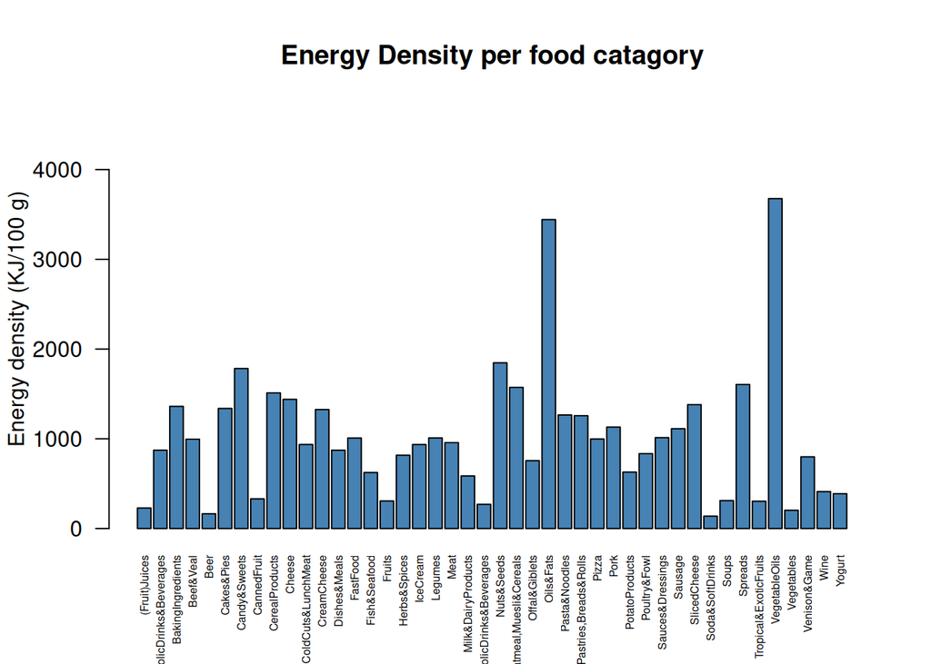

```r
barplot(df_ex11_summ$`Energy density (KJ/100 g)`,
        ylab = "Energy density (KJ/100 g)",
        ylim = c(0, max(df_ex11_summ$`Energy density (KJ/100 g)` + 1000)),
        names = df_ex11_summ$`FoodCategory`,
        las = 2,
        cex.names = 0.5,
        col = "steelblue",
        main = "Energy Density per food catagory")
```

Oils & Fats as well as VegetableOils show the highest mean energy density.

> This web page is distributed under the terms of the Creative Commons Attribution License which permits unrestricted use, distribution, and reproduction in any medium, provided the original author and source are credited. Creative Commons License: CC BY-SA 4.0.